# Technical Log

I then ran a correlation matrix and took a peak at the correlations greater than .3, which seems like a decent test value for this set. (I did also dig into the differences between high test scores and regular test scores again, but didn’t pursue this too far in the interest of brevity.)

```r
numeric_ten_earnings <- ten_earnings[ ,sapply(ten_earnings, is.numeric)]
correlation_matrix <- cor(numeric_ten_earnings, use="pairwise.complete.obs")
correlation_matrix[correlation_matrix[,"X10_yrs_after_entry.median"] > .3 & !is.na(correlation_matrix[, "X10_yrs_after_entry.median"]), "X10_yrs_after_entry.median"]
```

```
##                                        mn_earn_wne_p10
##                                              0.9780527
##                             X10_yrs_after_entry.median
##                                              1.0000000
##                                     pct10_earn_wne_p10
##                                              0.7484701
##                                     pct25_earn_wne_p10
##                                              0.7598444
##                                     pct75_earn_wne_p10
##                                              0.6973438
##                                     pct90_earn_wne_p10
##                                              0.6749324
##                                        sd_earn_wne_p10
##                                              0.7701989
##         X10_yrs_after_entry.percent_greater_than_25000
##                                              0.8722874
##       X10_yrs_after_entry.mean_earnings.lowest_tercile
##                                              0.5718616
##       X10_yrs_after_entry.mean_earnings.middle_tercile
##                                              0.5557066
##      X10_yrs_after_entry.mean_earnings.highest_tercile
##                                              0.5760008
##   X10_yrs_after_entry.mean_earnings.dependent_students
##                                              0.4571568
## X10_yrs_after_entry.mean_earnings.independent_students
##                                              0.4660199
##      X10_yrs_after_entry.mean_earnings.female_students
##                                              0.6083066
##        X10_yrs_after_entry.mean_earnings.male_students
##                                              0.6008925
##                         program_percentage.engineering
##                                              0.3184679
##                          program_percentage.biological
##                                              0.3239057
##                         program_percentage.mathematics
##                                              0.3603630
##                      program_percentage.social_science
##                                              0.3850026
##                  program_percentage.business_marketing
##                                              0.3002123
```

[output cut: 59 more lines]

```
##                                              0.3494520
##              median_debt_suppressed.completers.overall
##                                              0.3439875
##                              median_debt.noncompleters
##                                              0.4317297
##                        title_iv.still_enrolled_by.2yrs
##                                              0.5382367
##             title_iv.transf_still_enrolled_4yr_by.2yrs
##                                              0.3076789
##                  title_iv.transf_completed_4yr_by.3yrs
##                                              0.3000962
##                        title_iv.still_enrolled_by.3yrs
##                                              0.3933999
##                  title_iv.transf_completed_4yr_by.4yrs
##                                              0.3045642
```

```r
numeric_high_test_scores <- high_test_scores[ ,sapply(high_test_scores, is.numeric)]
high_correlation_matrix <- cor(numeric_high_test_scores, use="pairwise.complete.obs")

numeric_regular_test_scores <- regular_test_scores[ ,sapply(regular_test_scores, is.numeric)]
regular_correlation_matrix <- cor(numeric_regular_test_scores, use="pairwise.complete.obs")
```

We find in the data that two variables in particular are more strongly correlated than others with 10 year earnings. This is the faculty salary and what percentage of students remain at the institution after two years.

```r
enrolled_salary <- filter(ten_earnings, !is.na(title_iv.still_enrolled_by.2yrs), title_iv.still_enrolled_by.2yrs > 0, !is.na(faculty_salary), faculty_salary > 0)
```

The faculty salary and future earnings relationship was a bit muddied by the University of Phoenix. Due to their campuses being all over the country, but the earnings data was rolled up to an institutional level, it becomes difficult to make sense of their points, which come up in the upper left as lines of points.

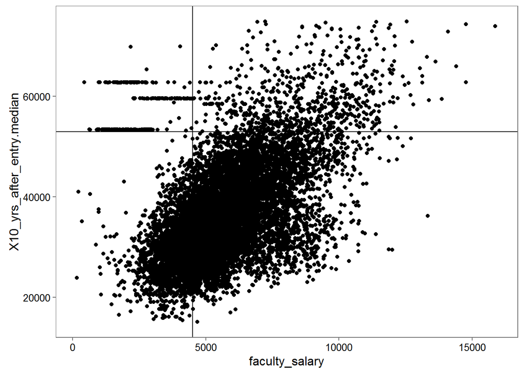

```r
#university of phoenix rolled it up to aggregate for earnings

ggplot(enrolled_salary) +
  geom_jitter(aes(x=faculty_salary, y=X10_yrs_after_entry.median)) +
  scale_y_continuous(limits=c(15000,75000)) +
  geom_hline(aes(yintercept=53000)) +
  geom_vline(aes(xintercept=4500))
```

For the relationship on two year retention rate:

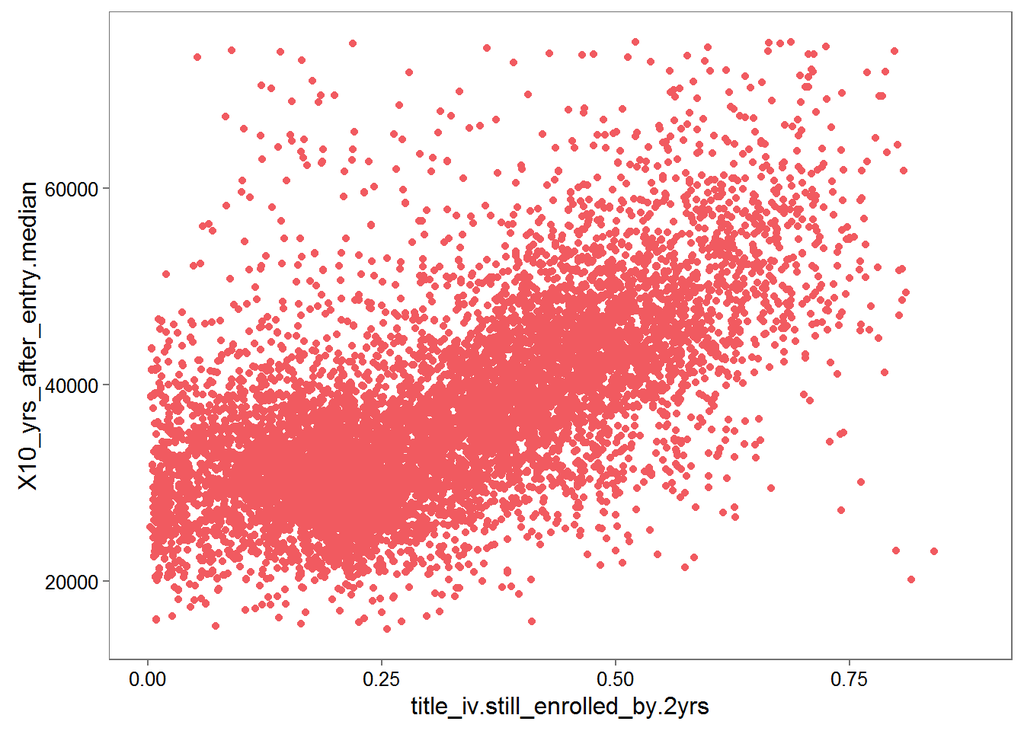

```r
ggplot(enrolled_salary) +
  geom_jitter(aes(x=title_iv.still_enrolled_by.2yrs, y=X10_yrs_after_entry.median, color=as.factor(1))) +
  scale_y_continuous(limits=c(15000,75000)) +
  scale_color_few() +
  guides(color=FALSE)
```

### Conclusion

I’ve only barely scratched the surface of what could be discovered in this dataset. Exploring the differences between the MIT type school and the regular school is something that could go on and on and yield a lot of interesting insights. Digging into different school segments through clustering analysis and finding out which features are predictive at different levels would be really useful for students of varying academic backgrounds.